# MATH 333 Project

C.J. Laws, Zack Roder, Graham Shank

4/20/2021

## Introduction and Motivation

In our project, we are interested in exploring the effects of NAFTA on US imports & exports to both Canada and Mexico. NAFTA, which went into effect in January 1994, established a free-trade zone on the North American continent.

To understand the effects of NAFTA on US trade with Canada and Mexico, we hope to develop a model of US exports/imports with the two nations using data prior to 1994. With a model, we could compare a forecast of imports/exports with the real post-1994 data to see if how significant of an effect NAFTA has had on North American trade.

We located our data on https://fred.stlouisfed.org. Units are US Dollars, Seasonally Adjusted.

## Data Cleaning and Initial Analysis

First, we clean the data so that we can load it into a ts object. First, it may be helpful to adjust the data for inflation (since it’s currently in nominal dollars) to remove at least some of the irregularity and better understand the dollar values. Using the priceR package, we can do this easily. We’ll convert each to 2019 dollars (last year of series). We then plot the data. After plotting the data, we can see that all series have a strong, upward trends. Somehow, we need to make these data stationary.

```
## Retrieving countries data
## Retrieving countries data
## Retrieving countries data
## Retrieving countries data
```

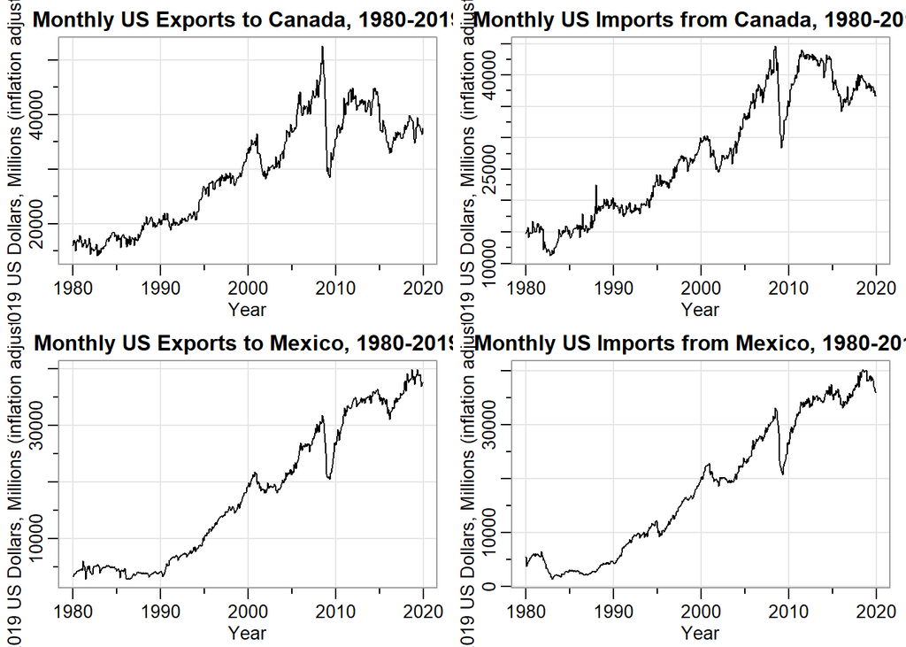

So that we have just one series to analyze, we can sum these four series to get a new series: US Total Trade with Mexico and Canada, Monthly. Furthermore, since we are particularly interested in pre-NAFTA data, we will splice the series.

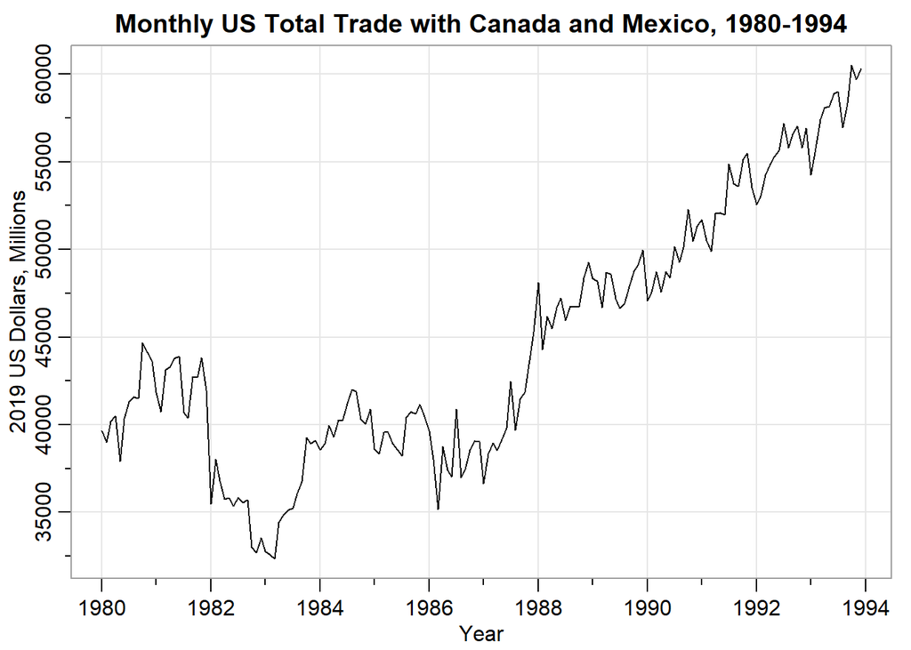

As we can see, this is not even close to being stationary. Hopefully, the difference and log transformation will coerce the data into being approximately stationary.

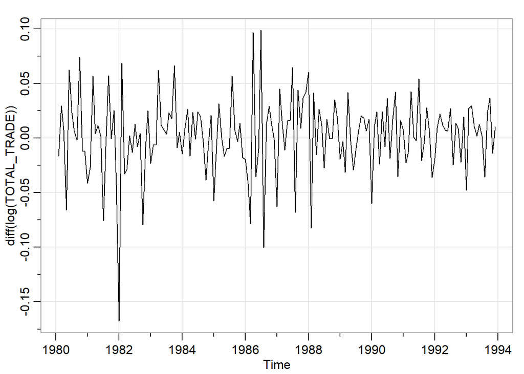

```r
tsplot(diff(log(TOTAL_TRADE)))
```

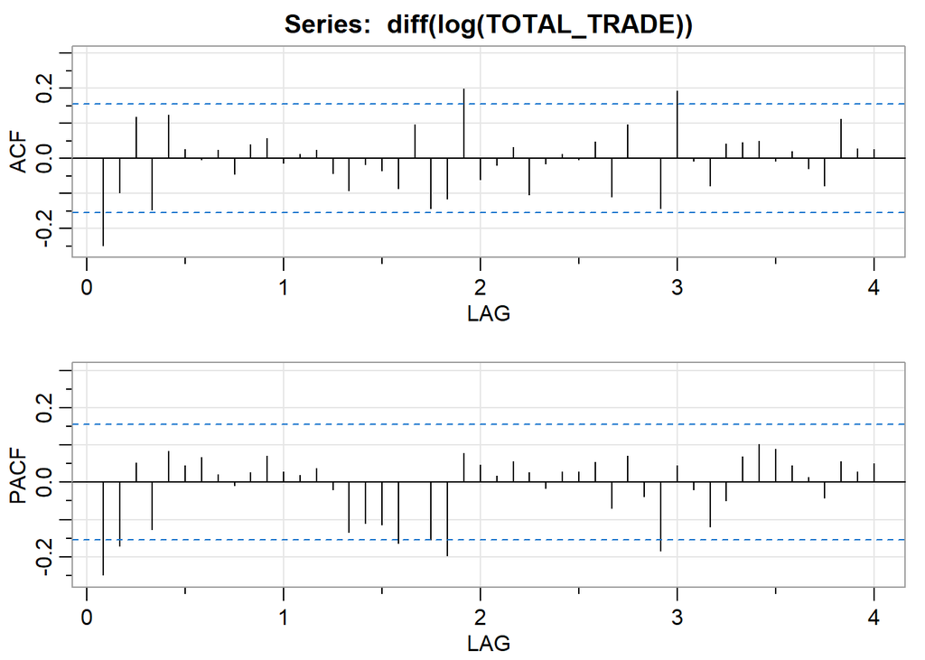

```r
acf2(diff(log(TOTAL_TRADE)))
```

The logged series with first difference applied appears approximately stationary, so we can proceed with building our model.

## Building a SARIMA model

To look for seasonal components for our model, we need to also account for seasonal differences in the series. Since this is monthly, we will take the lag 12 difference as well.

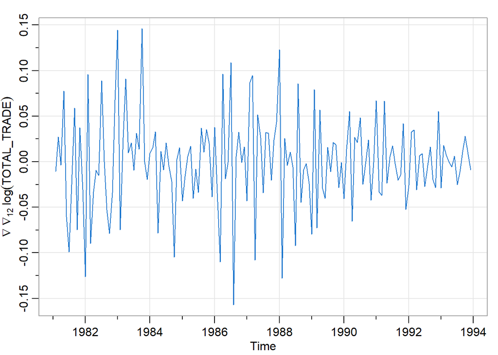

By evaluating the ACF/PACF, we should be able to determine the SARIMA components.

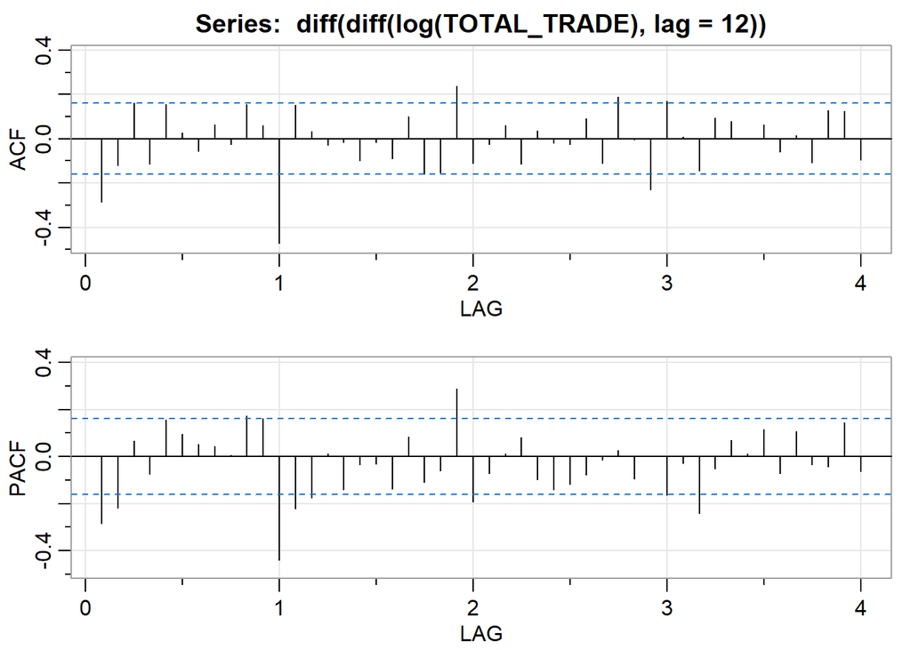

```r
acf2(diff(diff(log(TOTAL_TRADE), lag=12)))
```

To estimate the non-seasonal order of the SARIMA model, we inspect the first few lags. It appears that the PACF cuts off after lag 2. This suggests AR(2) within the season. Including a difference order, this gives us an estimate of ARIMA(2,1,0).

To estimate the seasonal order of the SARIMA model, we inspect the lags at 12s (s=1,2,…). At lag 1 (12 months), it appears that they both tail off, indicating ARMA. We will need to find the SAR and SMA orders through trial and error.

We will first try an $ARIMA(2,1,0) \times (1,1,1)_{12}$ model.

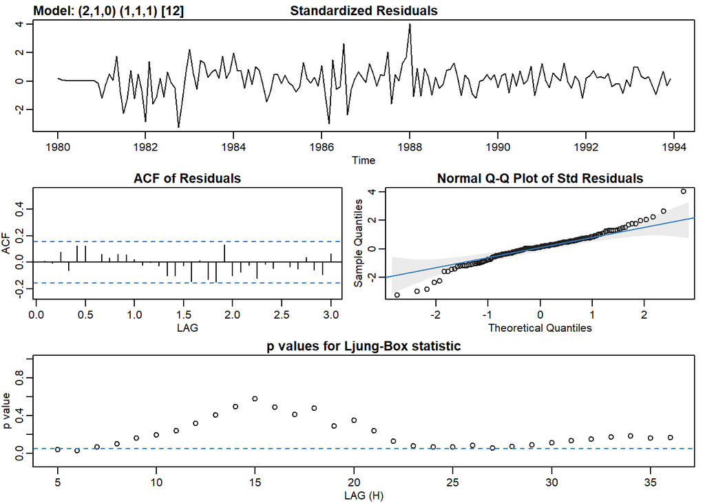

```
## $fit
##
## Call:
## stats::arima(x = xdata, order = c(p, d, q), seasonal = list(order = c(P, D,
##     Q), period = S), include.mean = !no.constant, transform.pars = trans, fixed = fixed,
##     optim.control = list(trace = trc, REPORT = 1, reltol = tol))
##
## Coefficients:
##           ar1      ar2     sar1     sma1
##       -0.3317  -0.1825  -0.0861  -0.9999
## s.e.   0.0788   0.0789   0.0835   0.1987
##
## sigma^2 estimated as 0.001006:  log likelihood = 298.09,  aic = -586.18
##
## $degrees_of_freedom
## [1] 151
##
## $ttable
##      Estimate     SE t.value p.value
## ar1   -0.3317 0.0788 -4.2086   0.000
## ar2   -0.1825 0.0789 -2.3141   0.022
## sar1  -0.0861 0.0835 -1.0315   0.304
## sma1  -0.9999 0.1987 -5.0328   0.000
##
## $AIC
## [1] -3.531189
##
## $AICc
## [1] -3.529692
##
## $BIC
## [1] -3.439519
```

```r
sarima(log(TOTAL_TRADE), 2, 1, 0, 1, 1, 1, 12)
```

The residuals for this model look okay, but we will see if adding another AR component within the season helps.

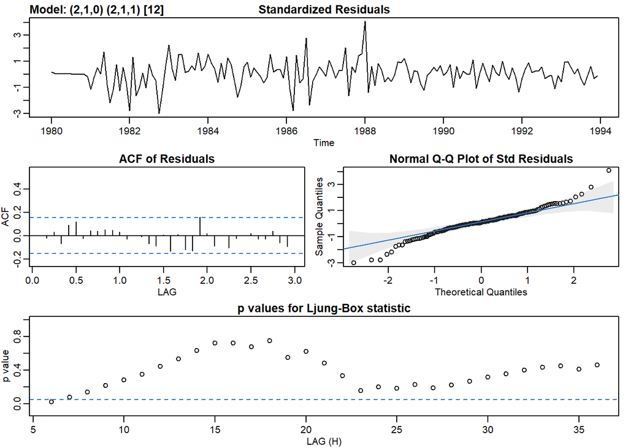

```
## $fit
##
## Call:
## stats::arima(x = xdata, order = c(p, d, q), seasonal = list(order = c(P, D,
##     Q), period = S), include.mean = !no.constant, transform.pars = trans, fixed = fixed,
##     optim.control = list(trace = trc, REPORT = 1, reltol = tol))
##
## Coefficients:
##           ar1      ar2     sar1     sar2     sma1
##       -0.3022  -0.1860  -0.2064  -0.2161  -0.8048
## s.e.   0.0802   0.0789   0.1263   0.1121   0.1470
##
## sigma^2 estimated as 0.001071:  log likelihood = 299.84,  aic = -587.69
##
## $degrees_of_freedom
## [1] 150
##
## $ttable
##      Estimate     SE t.value p.value
## ar1   -0.3022 0.0802 -3.7681  0.0002
## ar2   -0.1860 0.0789 -2.3578  0.0197
## sar1  -0.2064 0.1263 -1.6332  0.1045
## sar2  -0.2161 0.1121 -1.9282  0.0557
## sma1  -0.8048 0.1470 -5.4749  0.0000
##
## $AIC
## [1] -3.540292
##
## $AICc
## [1] -3.538033
##
## $BIC
## [1] -3.430288
```

```r
sarima(log(TOTAL_TRADE), 2, 1, 0, 2, 1, 1, 12)
```

Overall, this $ARIMA(2,1,0) \times (2,1,1)_{12}$ model appears pretty good. The ACF values for the residuals are all insignificant, and all but one of the Ljung-Box statistics are insignificant. The Q-Q plot appears reasonably normal aswell. Hence, we will proceed with this model for our forecast.

## Forecast

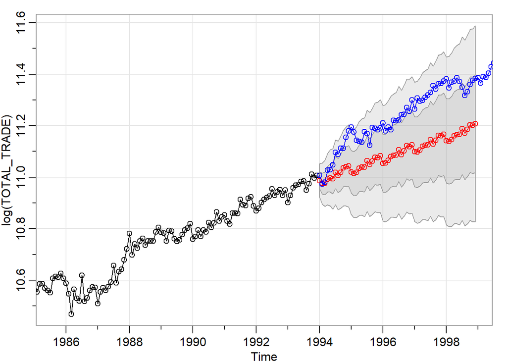

```r
mod <- sarima.for(log(TOTAL_TRADE), 60, 2, 1, 0, 2, 1, 1, 12)
lines(log(ts(TOTAL_TRADE_EXT[168:length(TOTAL_TRADE_EXT)], start=1994, freq=12)), type="o", col="blue")
```

## Other Methods We Tried

### Detrending

Because of the clear upward trend present in the series, we though that detrending (then developing an ARIMA model on the residuals) might be appropriate. However, we had mixed results.

First, we detrended the data:

```r
trend <- lm(TOTAL_TRADE ~  time(TOTAL_TRADE), na.action = NULL)
summary(trend)
```

```
##
## Call:
## lm(formula = TOTAL_TRADE ~ time(TOTAL_TRADE), na.action = NULL)
##
## Residuals:
##     Min      1Q  Median      3Q     Max
## -8189.7 -2396.5  -388.5  2686.4  9462.8
##
## Coefficients:
##                     Estimate Std. Error t value Pr(>|t|)
## (Intercept)       -2.942e+06  1.485e+05  -19.82   <2e-16 ***
## time(TOTAL_TRADE)  1.503e+03  7.472e+01   20.12   <2e-16 ***
## ---
## Signif. codes:  0 '***' 0.001 '**' 0.01 '*' 0.05 '.' 0.1 ' ' 1
##
## Residual standard error: 3914 on 166 degrees of freedom
## Multiple R-squared:  0.7092, Adjusted R-squared:  0.7074
## F-statistic: 404.8 on 1 and 166 DF,  p-value: < 2.2e-16
```

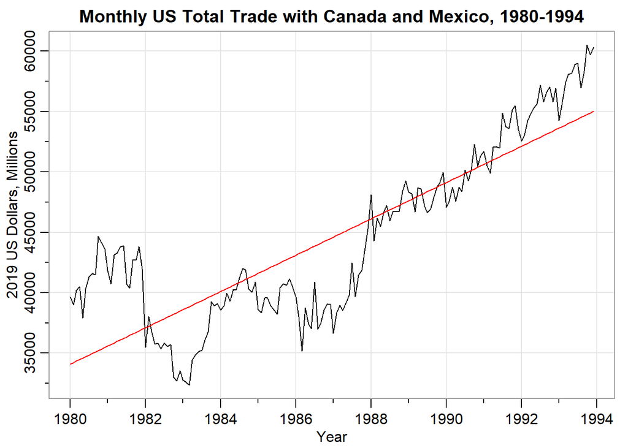

```r
tsplot(TOTAL_TRADE, main="Monthly US Total Trade with Canada and Mexico, 1980-1994", ylab="2019 US Dollars, Millions", xlab="Year")
lines(fitted(trend), col="red")
```

The linear model for the trend looks pretty solid, with significant coefficients. Next, we look at the plot of the residuals:

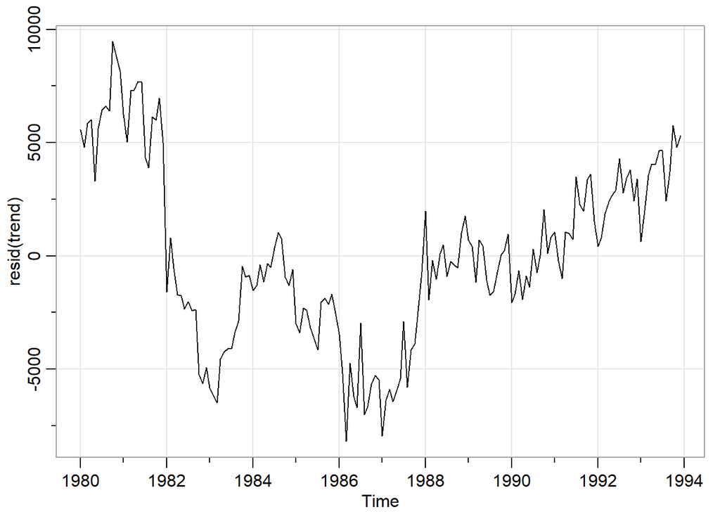

```r
tsplot(resid(trend))
```

This is obviously non-stationary, so we need to look at the difference.

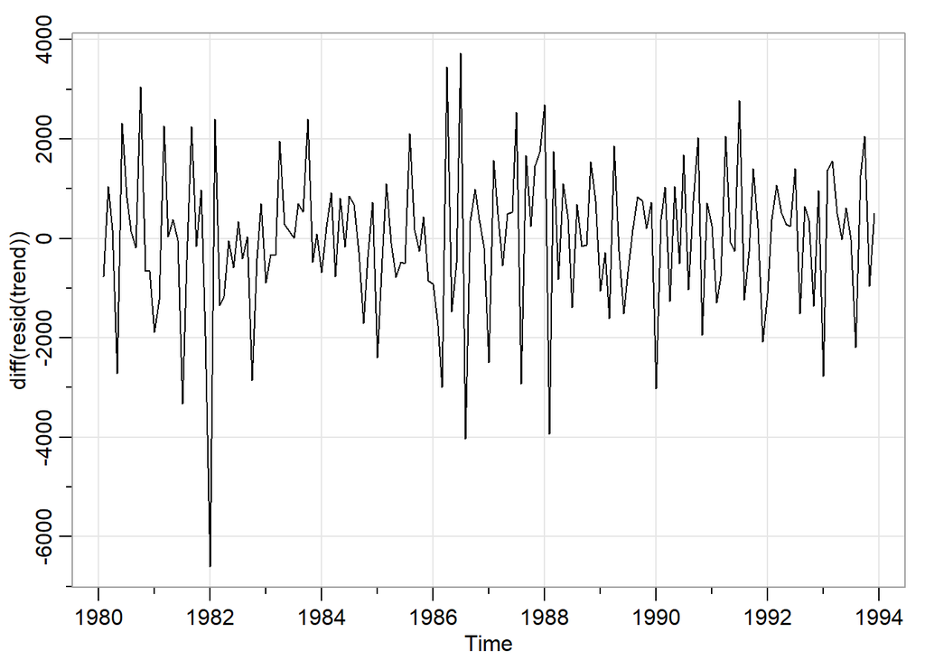

```r
tsplot(diff(resid(trend)))
```

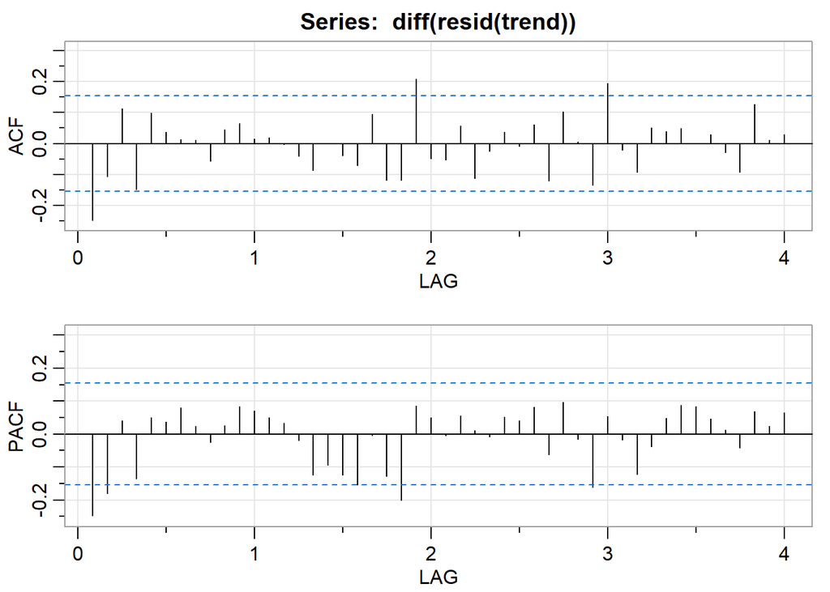

```
##       [,1]  [,2] [,3]  [,4] [,5] [,6] [,7] [,8]  [,9] [,10] [,11] [,12] [,13]
## ACF  -0.25 -0.11 0.11 -0.15 0.10 0.04 0.01 0.01 -0.06  0.04  0.07  0.02  0.02
## PACF -0.25 -0.18 0.04 -0.14 0.05 0.04 0.08 0.02 -0.02  0.03  0.08  0.07  0.05
##      [,14] [,15] [,16] [,17] [,18] [,19] [,20] [,21] [,22] [,23] [,24] [,25]
## ACF   0.00 -0.04 -0.09  0.00 -0.04 -0.07  0.09 -0.12 -0.12  0.21 -0.05 -0.05
## PACF  0.03 -0.02 -0.12 -0.09 -0.12 -0.15  0.00 -0.13 -0.20  0.09  0.05  0.00
##      [,26] [,27] [,28] [,29] [,30] [,31] [,32] [,33] [,34] [,35] [,36] [,37]
## ACF   0.06 -0.11 -0.02  0.04 -0.01  0.06 -0.12   0.1  0.01 -0.13  0.19 -0.02
## PACF  0.06  0.01 -0.01  0.05  0.04  0.08 -0.06   0.1 -0.02 -0.16  0.05 -0.02
##      [,38] [,39] [,40] [,41] [,42] [,43] [,44] [,45] [,46] [,47] [,48]
## ACF  -0.09  0.05  0.04  0.05  0.00  0.03 -0.03 -0.09  0.13  0.01  0.03
## PACF -0.12 -0.04  0.05  0.09  0.08  0.05  0.01 -0.04  0.07  0.02  0.07
```

```r
acf2(diff(resid(trend)))
```

```r
decompose(resid(trend))
```

```
## $x
##              Jan         Feb         Mar         Apr         May         Jun
## 1980  5564.75368  4794.46893  5842.71423  6017.31665  3305.42160  5625.10396
## 1981  6259.44329  5020.62612  7285.41055  7326.77461  7704.45286  7667.54637
## 1982 -1598.88729   800.50898  -544.24256 -1716.17435 -1759.80102 -2346.87017
## 1983 -5830.96788 -6155.46852 -6489.77735 -4538.66552 -4248.10747 -4104.31494
## 1984 -1532.18183 -1302.26322  -385.35771 -1155.11077  -343.87708  -512.22331
## 1985 -2996.67026 -3397.84838 -2297.11417 -2391.29065 -3176.85263 -3651.59164
## 1986 -3451.46590 -5194.91171 -8189.66911 -4734.30021 -6206.65185 -6694.00688
## 1987 -7955.61953 -6387.65438 -5897.40902 -6449.25170 -5955.41844 -5421.93969
## 1988  1983.56045 -1949.78530  -195.96017 -1017.69797    82.17083   478.86775
## 1989   710.74786   427.22117 -1177.62778   688.59515   437.81352 -1076.98323
## 1990 -2068.71401 -1687.84043  -651.13134 -1917.82985  -876.59766 -1381.56933
## 1991  1061.43400  -225.92441  -991.33695  1057.76256   975.81260   720.45658
## 1992   411.07236   790.14423  1857.94661  2374.76409  2653.38162  2889.44809
```

[output cut: 152 more lines]